# Module 3 Team Assignment

Abdoul Diagne, Jacqueline Garcia, Vanessa Garner, Fatima Saleem, Jenna Swiecki, Bryan Yang

2022-09-25

### Part 1 - P-Card Internal Control Test

- 1a. Paste the code to arrive at your list of 10 to 20 rows to your report.

```r
library(tidyverse)
df <- read_rds("class_data_pcard_data_forNLP.rds")

# clean data
df1 <- df %>% select(-Agency.Number, -Agency.Description, -Posting.Date, -Month, -Weekday, -Day.Month)

# combine all strings into one column
df1 <- df1 %>%
  mutate(df1 %>% select(Item.Description, Merchant, MCC) %>%
         tidyr::unite(all_text, sep = ' ', remove = T, na.rm = T)
         )

# create regex pattern
pattern <- "\\bWINE|\\bBEER|\\bALCOHOL|\\bSPIRITS|\\bATM\\b|\\bCASH\b|\\bMONEY|\\bSTAMP\\b|POSTAGE|\\bUNIFORM|\\bAMMUNITION|\\bAMMO\\b|\\bGUN\\b|\\bFINES|CIGAR|TRAILER PARK|\\bINSURANCE|MASSAGE|CONVENTION|CONFERENCE|\\bPRIME\\b|MEMBERSHIP|GIFT|DECORATIONS|DATA PLAN|PREPAYMENT|DEPOSIT|DONATION|INCENTIVE AWARD|EMPLOYEE SERVICE|GASOLINE|FUEL|SALES TAX|MOVING EXPENSE|PERSONAL|HEALTH CARE|CANDY|FLOWERS|GREETING CARD|LATE FEES|REBATES|REWARDS|CASH BACK|SPLIT PURCHASE|SALARY|WAGES|BENEFITS"

# create new column if problematic words exists & keep only problematic rows
df1a <- df1 %>%
  mutate(problem = str_count(all_text, pattern))

# filter
df_problems <- df1a %>% filter(problem > 0)

# eliminate false positives
df_problems %>%
  select(Cardholder.Name, Item.Description, Amount, Merchant, MCC, problem) %>%
  arrange(MCC, desc(Amount))
```

```
## # A tibble: 3,156 × 6
##    Cardholder.Name     Item.Description            Amount Merchant MCC   problem
##    <chr>               <chr>                        <dbl> <chr>    <chr>   <int>
##  1 VICOSA BAUERMANN, F ETHYL ALCOHOL PURE 200 EA     70.1 SIGMA A… ALL …       1
##  2 SETHURAMAN, S       POLY(VINYL ALCOHOL) 87-9 EA   58.6 SIGMA A… ALL …       1
##  3 BECK, S             GENERAL PURCHASE             908.  MATHIS … AUTO…       1
##  4 HUNTER, J           GENERAL PURCHASE              53.6 EXXONMO… AUTO…       1
##  5 CHAMBERS, M         GENERAL PURCHASE              36   SHELL O… AUTO…       1
##  6 COTTRILL, J         GENERAL PURCHASE              34.3 EXXONMO… AUTO…       1
##  7 WILSON, A           GENERAL PURCHASE              23.0 SHELL O… AUTO…       1
##  8 PESTRAK, S          GENERAL PURCHASE              22.9 SHELL O… AUTO…       1
##  9 COTTRILL, J         GENERAL PURCHASE              22.4 CHEVRON… AUTO…       1
## 10 KEPPLE, M           GENERAL PURCHASE              22   LOVE S … AUTO…       1
## # … with 3,146 more rows
```

```r
# eliminate rows that are not a problem and then check again
safe_words <- "ISOPROPYL|SPRY GUN|CAULK GUN|BLOWGUN|HAND SANITIZER|HAND SANITIZI|ALCOHOL WIPES|HEAT GUN|DISINFECTANT|MINERAL SPIRITS|DISINFECTA|ETHYL|GLUE GUN|STAPLE GUN|RUBBING ALCOHOL|LCOHOL WET WIPES|ALCOHOL REAGENT|ALCOHOL PREP|DENATURED ALCOHOL|BLOW GUN|VINYL ALCOHOL|ALCOHOL RESISTANT|ALCOHOL WIPE|ALCOHOL-RE|GUN BALLING|SPRAY GUN|BEER PING|TAPE DISP|MONEY BANK BAG|RACISM ANTIRACIS|RUBBERSTAMPS|AMYL ALCOHOL|RUBBER STAMP|ALCOHOL WIP|GLUE GUN|BDH|ALCOHOL DISPENSER|UNIVERSITY|RANCHERS CLUB|UNIVERSITY DINING|RENTAL CAR|RENTAL VEHICLE|LAB|LAWN|INSTITUTIONAL"

# keep only rows without safe words in them
df_problems <- df_problems %>%
  filter(str_detect(all_text, safe_words) == F)

# look at the potential violations that are high in amount
df_problems <- df_problems %>%
  select(Cardholder.Name, Item.Description, Amount, Merchant, Transaction.Date, MCC, problem) %>%
  filter(Amount > 800) %>%
  arrange(desc(Amount))
```

```r
# problematic MCC Code Analysis
# Get list of unique MCCs
df2 <- df_problems %>% arrange(MCC)
n_distinct(df2$MCC)
```

```
## [1] 30
```

```r
unique(df2$MCC)
```

```
##  [1] "AUTOMATED FUEL DISPENSERS"
##  [2] "BOOK STORES"
##  [3] "BUSINESS SERVICES NOT ELSEWHERE CLASSIFI"
##  [4] "CHARITABLE AND SOCIAL SERVICE ORGANIZATI"
##  [5] "COLLEGES UNIVERSITIES PROFESSIONAL SCH"
##  [6] "COMMERCIAL EQUIPMENT, NOT ELSEWHERE CLAS"
##  [7] "COMPUTER SOFTWARE STORES"
##  [8] "DRINKING PLACES (ALCOHOLIC BEV.)-BARS TA"
##  [9] "EATING PLACES RESTAURANTS"
## [10] "EQUIP RENTALS & LEASING SERVICES, TOOL R"
## [11] "FLORISTS"
## [12] "GIFT CARD NOVELTY AND SOUVENIR SHOPS"
## [13] "GIFT, CARD, NOVELTY, AND SOUVENIR SHOPS"
## [14] "HOME SUPPLY WAREHOUSE STORES"
## [15] "INSURANCE-SALES & UNDERWRITING"
## [16] "MANAGEMENT, CONSULTING AND PUBLIC RELATI"
## [17] "MEMBERSHIP CLUBS (SPORTS RECREATION ATHL"
## [18] "MEMBERSHIP CLUBS,(SPORTS,RECREATION,ATHL"
## [19] "MEMBERSHIP ORGANIZATIONS NOT ELSEWHERE C"
## [20] "MEN S WOMENS AND CHILDREN S UNIFORMS AND"
## [21] "MEN'S,WOMENS'AND CHILDREN'S UNIFORMS AND"
## [22] "MISCELLANEOUS GENERAL MERCHANDISE STORES"
## [23] "MISCELLANEOUS PERSONAL SERVICES"
## [24] "MISCELLANEOUS PUBLISHING & PRINTING"
## [25] "MISCELLANEOUS REPAIR SHOPS AND RELATED S"
## [26] "MISCELLENEOUS APPAREL AND ACCESSORY STOR"
## [27] "PACKAGE STORES BEER LIQUOR"
## [28] "POSTAGE STAMPS"
## [29] "PROFESSIONAL SERVICES NOT ELSEWHERE CLAS"
## [30] "SCHOOLS AND EDUCATIONAL SERVICES NOT ELS"
```

```r
# Trim white spaces
df2 <- df2 %>% mutate(MCC2 = str_trim(MCC, side='both'))

# Replac punctuation with ''
df2 <- df2 %>% mutate(MCC2 = str_replace_all(MCC2, '[:punct:]', ''))

n_distinct(df2$MCC2)
```

```
## [1] 29
```

```r
unique(df2$MCC2)
```

```
##  [1] "AUTOMATED FUEL DISPENSERS"
##  [2] "BOOK STORES"
##  [3] "BUSINESS SERVICES NOT ELSEWHERE CLASSIFI"
##  [4] "CHARITABLE AND SOCIAL SERVICE ORGANIZATI"
##  [5] "COLLEGES UNIVERSITIES PROFESSIONAL SCH"
##  [6] "COMMERCIAL EQUIPMENT NOT ELSEWHERE CLAS"
##  [7] "COMPUTER SOFTWARE STORES"
##  [8] "DRINKING PLACES ALCOHOLIC BEVBARS TA"
##  [9] "EATING PLACES RESTAURANTS"
## [10] "EQUIP RENTALS  LEASING SERVICES TOOL R"
## [11] "FLORISTS"
## [12] "GIFT CARD NOVELTY AND SOUVENIR SHOPS"
## [13] "HOME SUPPLY WAREHOUSE STORES"
## [14] "INSURANCESALES  UNDERWRITING"
## [15] "MANAGEMENT CONSULTING AND PUBLIC RELATI"
## [16] "MEMBERSHIP CLUBS SPORTS RECREATION ATHL"
## [17] "MEMBERSHIP CLUBSSPORTSRECREATIONATHL"
## [18] "MEMBERSHIP ORGANIZATIONS NOT ELSEWHERE C"
## [19] "MEN S WOMENS AND CHILDREN S UNIFORMS AND"
## [20] "MENSWOMENSAND CHILDRENS UNIFORMS AND"
## [21] "MISCELLANEOUS GENERAL MERCHANDISE STORES"
## [22] "MISCELLANEOUS PERSONAL SERVICES"
## [23] "MISCELLANEOUS PUBLISHING  PRINTING"
## [24] "MISCELLANEOUS REPAIR SHOPS AND RELATED S"
## [25] "MISCELLENEOUS APPAREL AND ACCESSORY STOR"
## [26] "PACKAGE STORES BEER LIQUOR"
## [27] "POSTAGE STAMPS"
## [28] "PROFESSIONAL SERVICES NOT ELSEWHERE CLAS"
## [29] "SCHOOLS AND EDUCATIONAL SERVICES NOT ELS"
```

```r
# Keep problematic MCCs
# Make list of problematic MCCs
mcc_list = c('STEAMSHIP LINESCRUISE LINES',
             'TELEGRAPH SERVICES',
             'WIRE TRANSFER  MONEY ORDERS',
             'DUTY FREE STORES',
             'COCKTAIL LOUNGES BARS  ALCOHOLIC BEVERAGES',
             'DIGITAL GOODS MEDIA BOOKS MOVIES, MUSIC',
             'DIGITAL GOODS GAMES',
             'PACKAGE STORES  BEER WINE AND LIQUOR',
             'PAWN SHOPS',
             'DIRECT MARKETING INSURANCE SERVICES',
             'CIGAR STORES  STANDS',
             'FINANCIAL INSTITUTIONS  MANUAL CASH DISBURSEMENTS',
             'FINANCIAL INSTITUTIONS  AUTOMATED CASH DISBURSEMENTS',
             'FINANCIAL INSTITUTIONS  MERCHANDISE AND SERVICES',
             'NON-FINANCIAL INSTITUTIONS  FOREIGN CURRENCY, CHEQUES',
             'SECURITY BROKERSDEALERS',
             'INSURANCE SALES UNDERWRITING AND PREMIUMS',
             'INSURANCE PREMIUMS',
             'INSURANCE  NOT ELSEWHERE CLASSIFIED',
             'INSURANCESALES & UNDERWRITING',
             'REMOTE STORED VALUE  MEMBER FINANCIAL INSTITUTION',
             'REMOTE STORED VALUE  MERCHANT',
             'PAYMENT SERVICE PROVIDER',
             'PAYMENT TRANSACTION  MEMBER FINANCIAL INSTITUTION',
             'PAYMENT TRANSACTION  MERCHANT',
             'MASTERCARD INITIATED REBATE/REWARDS',
             'TIMESHARES',
             'SPORTING  RECREATIONAL CAMPS',
             'TRAILER PARKS  CAMPGROUNDS',
             'ESCORT SERVICES',
             'DATING  ESCORT SERVICES',
             'TAX PREPARATION SERVICE',
             'COUNSELING SERVICE  DEBT, MARRIAGE, PERSONAL',
             'BABYSITTING SERVICES',
             'MASSAGE PARLORS',
             'SPAS  HEALTH  BEAUTY',
             'MOTORHOME  RECREATIONAL VEHICLE RENTAL',
             'GOVERNMENTOWNED LOTTERIES',
             'GOVERNMENTLICENSED CASINOS ONLINE GAMBLING',
             'GOVERNMENTLICENSED HORSE/DOG RACING',
             'VIDEO RENTAL STORES',
             'DANCE HALLS STUDIOS  SCHOOLS',
             'BILLIARD  POOL ESTABLISHMENTS',
             'TOURIST ATTRACTIONS  EXHIBITS',
             'GOLF COURSES  PUBLIC',
             'VIDEO AMUSEMENT GAME SUPPLIES',
             'VIDEO GAME ARCADESESTABLISHMENTS',
             'BETTING INCLUDING LOTTERY TICKETS',
             'AMUSEMENT PARKS CIRCUSES  CARNIVALS',
             'MEMBERSHIP CLUBS SPORTS, RECREATION, ATHLETIC',
             'AQUARIUMS SEAQUARIUMS DOLPHINARIUMS',
             'ZOOS AMUSEMENT  RECREATION SERVICES',
             'COURT COSTS ALIMONY CHILD SUPPORT',
             'FINES',
             'BAIL AND BOND PAYMENTS',
             'IPURCHASING PILOT',
             'GOVERNMENT LOAN PAYMENTS',
             'AUTOMATED REFERRAL SERVICE',
             'VISA CREDENTIAL SERVER',
             'GCAS EMERGENCY SERVICES',
             'UK SUPERMARKETS ELECTRONIC HOT FILE',
             'UK PETROL STATIONS ELECTRONC HOT FILE',
             'GAMBLING  HORSEDOG RACING  STATE LOTTERY',
             'INTRACOMPANY PURCHASES',
             'CLIENT DEFINED MCC',
             'DRINKING PLACES ALCOHOLIC BEVBARS TA',
             'DIGITAL GOODS  GAMES',
             'DIGITAL GOODS  MEDIA BOOKS MOVIES MUSIC',
             'DIGITAL GOODS  MEDIABOOKSMOVIES,MUSIC',
             'PACKAGE STORES BEER LIQUOR',
             'CIGAR STORES AND STANDS',
             'INSURANCESALES  UNDERWRITING',
             'SPORTING AND RECREATIONAL CAMPS',
             'TRAILER PARKS AND CAMPGROUNDS',
             'COUNSELING SERVICEDEBT MARRIAGE PERSO',
             'HEALTH AND BEAUTY SPAS',
             'MOTOR HOME AND RECREATIONAL VEHICLE RENT',
             'BEAU RIVAGE HOTEL AND CASINO',
             'LUXOR HOTEL AND CASINO',
             'MIRAGE HOTEL AND CASINO',
             'VIDEO AMUSEMENT GAME SUPPLIES',
             'VIDEO RENTAL STORES',
             'DANCE HALLS STUDIOS AND SCHOOLS',
             'DANCE HALLS STUDIOS AND SCHOOLS',
             'BILLIARD AND POOL ESTABLISHMENTS',
             'TOURIST ATTRACTIONS AND EXHIBITS',
             'GOLF COURSESPUBLIC',
             'AMUSEMENT PARKS CIRCUSES CARNIVALS FO',
             'AMUSEMENT RECREATION SERVICES SWIMMING',
             'AMUSEMENTRECREATION SERVICES (SWIMMING',
             'MEMBERSHIP CLUBSSPORTSRECREATION,ATHL',
             'MEMBERSHIP CLUBS SPORTS RECREATION ATHL',
             'CHILD CARE SERVICES')
```

```r
# Keep only problematic ones
mcc_problems <- df2 %>% filter(MCC2 %in% mcc_list)

# view
mcc_problems %>% select(Cardholder.Name, Item.Description, Amount, Merchant, MCC2) %>%
  arrange(MCC2, Merchant, desc(Amount))
```

```
## # A tibble: 10 × 5
##    Cardholder.Name Item.Description        Amount Merchant                 MCC2
##    <chr>           <chr>                    <dbl> <chr>                    <chr>
##  1 PETERS, B       DRINKS1589484011220 NMB   980  SQ PRAIRIE WOLF SPIRITS  DRIN…
##  2 KISSMAN CH, A   GENERAL PURCHASE         1362. EQUISURE, INC.           INSU…
##  3 GERLT, T        GENERAL PURCHASE         3017  UNITEDHEALTHCARE INS     INSU…
##  4 MARTIN, D       GENERAL PURCHASE         2400  B & V BODY WORKS GYM LLC MEMB…
##  5 LOCKWOOD, B     GENERAL PURCHASE         1018. RANGERS FC               MEMB…
##  6 BROWNFIELD, K   GENERAL PURCHASE          806. BEELINE LIQUOR STORE     PACK…
##  7 COLLINS, A      GENERAL PURCHASE         1226. BROWNS BOTTLE SHOP       PACK…
##  8 COLLINS, A      GENERAL PURCHASE         1183. BROWNS BOTTLE SHOP       PACK…
##  9 COLLINS, A      GENERAL PURCHASE         1108  BROWNS BOTTLE SHOP       PACK…
## 10 COLLINS, A      GENERAL PURCHASE          967. BROWNS BOTTLE SHOP       PACK…
```

```r
# Especially problematic
mcc_problems <- mcc_problems %>% select(Cardholder.Name, Item.Description, Amount, Merchant, Transaction.Date, MCC2) %>%
  filter(Amount > 800) %>%
  arrange(desc(Amount))
```

- 1b. Print/display your 10 to 20 rows in your notebook. These rows are a list of transactions, not a list of MCCs.

```r
mcc_problems [1:10,]
```

```
## # A tibble: 10 × 6
##    Cardholder.Name Item.Description       Amount Merchant Transaction.Date MCC2
##    <chr>           <chr>                   <dbl> <chr>    <date>           <chr>
##  1 GERLT, T        GENERAL PURCHASE        3017  UNITEDH… 2020-12-04       INSU…
##  2 MARTIN, D       GENERAL PURCHASE        2400  B & V B… 2020-01-31       MEMB…
##  3 KISSMAN CH, A   GENERAL PURCHASE        1362. EQUISUR… 2020-09-22       INSU…
##  4 COLLINS, A      GENERAL PURCHASE        1226. BROWNS … 2020-01-27       PACK…
##  5 COLLINS, A      GENERAL PURCHASE        1183. BROWNS … 2020-02-13       PACK…
##  6 COLLINS, A      GENERAL PURCHASE        1108  BROWNS … 2020-02-28       PACK…
##  7 LOCKWOOD, B     GENERAL PURCHASE        1018. RANGERS… 2020-02-03       MEMB…
##  8 PETERS, B       DRINKS1589484011220 N…   980  SQ PRAI… 2020-05-14       DRIN…
##  9 COLLINS, A      GENERAL PURCHASE         967. BROWNS … 2020-02-28       PACK…
## 10 BROWNFIELD, K   GENERAL PURCHASE         806. BEELINE… 2020-03-04       PACK…
```

- 1c. Write a paragraph to describe how you found these 10 to 20 rows and why these rows are your most problematic. Top answers will use categories and/or words that I did not discuss in class, clearly discuss why these categories/words were problematic, and how the group selected these.

**Using the pattern of problematic words and safe_words created a summary of problematic words and eliminated the false positives. Then we focused on the high value items (>800). Our group also added more problematic and safe words based on observations of the data such as “CONVENTION|CONFERENCE|\bPRIME\b|MEMBERSHIP|GIFT|DECORATIONS|DATA PLAN|PREPAYMENT|DEPOSIT|DONATION|INCENTIVE AWARD|EMPLOYEE SERVICE|GASOLINE|FUEL|SALES TAX|MOVING EXPENSE|PERSONAL|HEALTH CARE|CANDY|FLOWERS|GREETING CARD|LATE FEES|REBATES|REWARDS|CASH BACK|SPLIT PURCHASE|SALARY|WAGES|BENEFITS” for problematic words and “BDH|ALCOHOL DISPENSER|UNIVERSITY|RANCHERS CLUB|UNIVERSITY DINING|RENTAL CAR|RENTAL VEHICLE|LAB|LAWN|INSTITUTIONAL” for safe words. We believe these words were most problematic because they were most frequently recurring and high dollar value.**

- 1d. In one or two paragraphs, describe what questions you would ask management in order to determine if these transactions are indeed violation of the P-Card controls (that is, they are prohibited goods, services, and/or prohibited “MCC’s”). Top answers will have specific questions for management, e.g., “when are ____ purchases allowed,” etc.
1. When are uniforms purchases allowed?
2. When are stamps purchases allowed?
3. When are book purchases allowed?
4. When are health insurance premium payments allowed?
5. When are alternative accommodation payments allowed, such as campgrounds in lieu of hotels?

### Part 2 - Apple’s MD&A Sentiment Analysis

```r
# load packages
library(tidytext)
library(SnowballC)
library(wordcloud)
library(Rcpp)
library(RColorBrewer)
library(textdata)

# read the files into the markdown file
mda <- read_file("MDA.txt")
press_release <- read_file("press_release.txt")

nchar(mda)
```

```
## [1] 26216
```

```r
nchar(press_release)
```

```
## [1] 1926
```

- 2a. Following the code from the Coursera video, make the MD&A text a tibble, tokenize the string into words, remove stop words, and add sentiment. Then, graph the percentages of the sentiment categories in a stacked bar chart, as done in the Coursera video.

```r
# Tokenize the text
# charge to a tibble (tidy dataframe)
mda_tokens <- tibble(mda)

# tokenize
mda_tokens <- mda_tokens %>% tidytext::unnest_tokens(output=word, input=mda, token='words', to_lower=T)

# add order of words
mda_tokens <- mda_tokens %>% mutate(order = row_number())

# count the number of matches of a substring
mda_tokens %>% dplyr::filter(word == str_sub('covid')) %>% count()
```

```
## # A tibble: 1 × 1
##       n
##   <int>
## 1     6
```

```r
# location of the keyword mentioned
mda_tokens %>% dplyr::filter(word == str_sub('covid'))
```

```
## # A tibble: 6 × 2
##   word  order
##   <chr> <int>
## 1 covid   125
## 2 covid   129
## 3 covid   172
## 4 covid   194
## 5 covid   246
## 6 covid   372
```

```r
# Remove stop words
# load custom stopwords
custom_stop_words <- read_csv("stop_words_list.csv", col_names = F)
# remove stop words
mda_tokens <- mda_tokens %>%
  anti_join(custom_stop_words, by = c('word'='X1'))

mda_tokens %>% nrow()
```

```
## [1] 2256
```

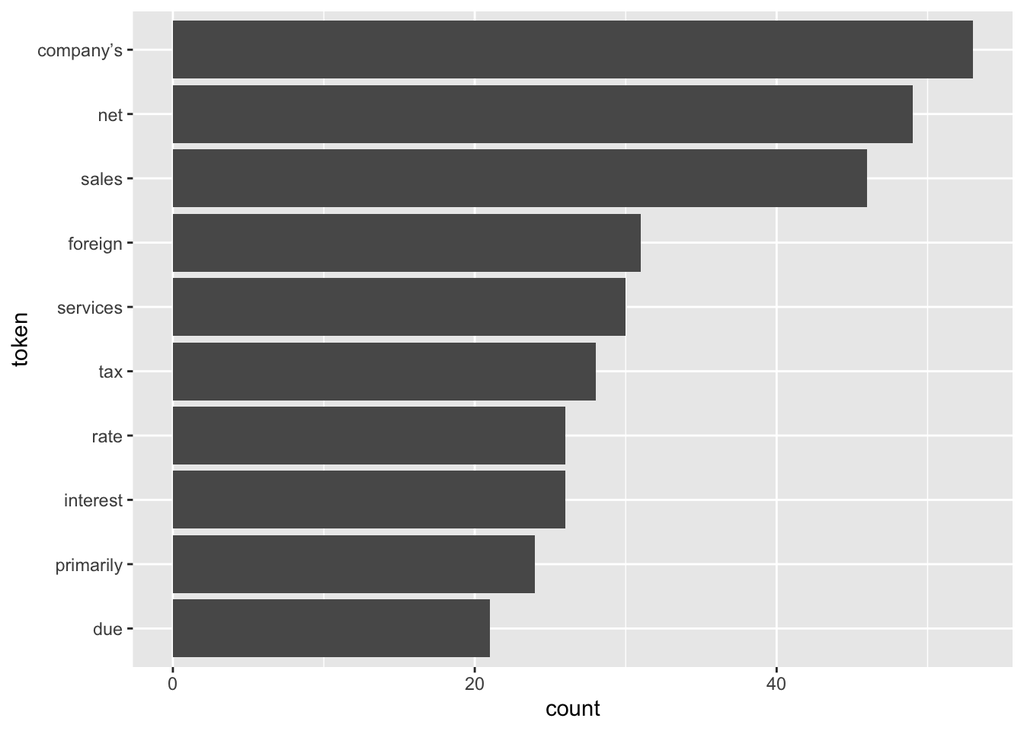

```r
mda_tokens %>%
  group_by(word) %>%
  summarize(count = n()) %>%
  arrange(desc(count)) %>%
  filter(count > 20) %>%
  mutate(token = reorder(word, count)) %>%
  ggplot(aes(x=count, y=token)) + geom_col()
```

```r
# Stemming and Lemmatizing
# stem the tokens
mda_stemmed <- mda_tokens %>% mutate(stem = SnowballC::wordStem(word))

# look at similar words
arrange(mda_stemmed, word)[316:325,]
```

```
## # A tibble: 10 × 3
##    word     order stem
##    <chr>    <int> <chr>
##  1 amount    2150 amount
##  2 amount    2837 amount
##  3 amount    3170 amount
##  4 amount    3314 amount
##  5 amount    3889 amount
##  6 amounts   2573 amount
##  7 analyses  3871 analys
##  8 analysis     6 analysi
##  9 analysis    92 analysi
## 10 analysis  2552 analysi
```

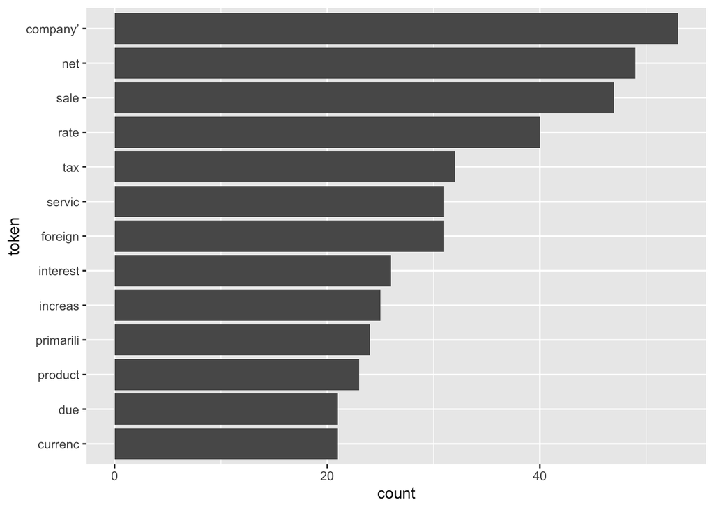

```r
mda_stemmed %>%
  group_by(stem) %>%
  summarize(count = n()) %>%
  arrange(desc(count)) %>%
  filter(count > 20) %>%
  mutate(token = reorder(stem, count)) %>%
  ggplot(aes(x=count, y=token)) + geom_col()
```

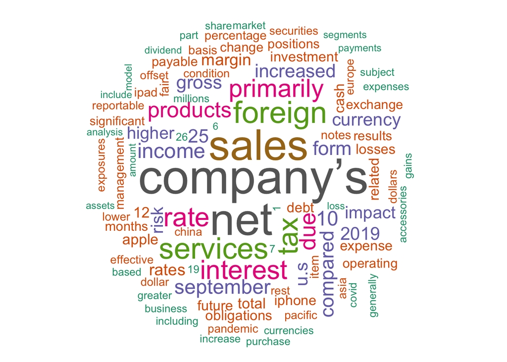

```r
# Key words
set.seed(77)

mda_stemmed %>%
  group_by(word) %>%
  summarize(count = n()) %>%
  with(wordcloud(words=word, freq=count, min.freq=1, max.words=100, random.order=F, rot.per=0.30, colors=brewer.pal(8, "Dark2")))
```

```r
# Sentiment total
# load finance sentiment list and explore it
lm_dict <- tidytext::get_sentiments('loughran')

# view dictionary
lm_dict %>% group_by(sentiment) %>% summarize(count = n())
```

```
## # A tibble: 6 × 2
##   sentiment    count
##   <chr>        <int>
## 1 constraining   184
## 2 litigious      904
## 3 negative      2355
## 4 positive       354
## 5 superfluous     56
## 6 uncertainty    297
```

```r
# add sentiment
mda_sentimented <- mda_stemmed %>%
  inner_join(lm_dict, by = 'word')

# explore totals
mda_sentimented %>% group_by(sentiment) %>% summarize(count = n())
```

```
## # A tibble: 6 × 2
##   sentiment    count
##   <chr>        <int>
## 1 constraining    30
## 2 litigious       16
## 3 negative        38
## 4 positive        33
## 5 superfluous      1
## 6 uncertainty     58
```

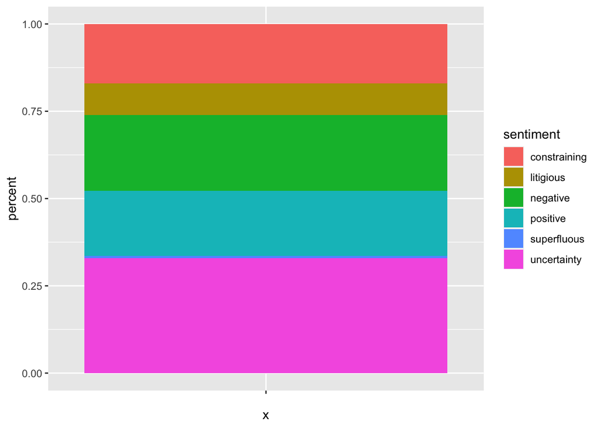

```r
mda_sentimented %>%
  group_by(sentiment) %>%
  summarize(count = n(), percent = count/nrow(mda_sentimented)) %>%
  ggplot(aes(x='', y=percent, fill=sentiment)) +
  geom_bar(width=1, stat='identity')
```

- 2b. Do the same thing for the press release.

```r
# Tokenize the text
# charge to a tibble (tidy dataframe)
pr_tokens <- tibble(press_release)

# tokenize
pr_tokens <- pr_tokens %>% tidytext::unnest_tokens(output=word, input=press_release, token='words', to_lower=T)

# add order of words
pr_tokens <- pr_tokens %>% mutate(order = row_number())

# count the number of matches of a substring
pr_tokens %>% dplyr::filter(word == str_sub('coivd')) %>% count()
```

```
## # A tibble: 1 × 1
##       n
##   <int>
## 1     0
```

```r
# location of the keyword mentioned
pr_tokens %>% dplyr::filter(word == str_sub('covid'))
```

```
## # A tibble: 0 × 2
## # … with 2 variables: word <chr>, order <int>
```

```r
# Remove stop words
pr_tokens <- pr_tokens %>%
  anti_join(custom_stop_words, by = c('word'='X1'))

pr_tokens %>% nrow()
```

```
## [1] 163
```

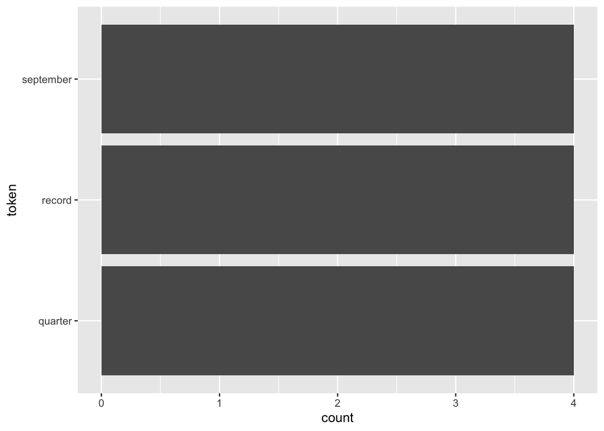

```r
pr_tokens %>%
  group_by(word) %>%
  summarize(count = n()) %>%
  arrange(desc(count)) %>%
  filter(count > 3) %>%
  mutate(token = reorder(word, count)) %>%
  ggplot(aes(x=count, y=token)) + geom_col()
```

```r
# Stemming and Lemmatizing
# stem the tokens
pr_stemmed <- pr_tokens %>% mutate(stem = SnowballC::wordStem(word))

# look at similar words
arrange(pr_stemmed, word)[1:20,]
```

```
## # A tibble: 20 × 3
##    word      order stem
##    <chr>     <int> <chr>
##  1 0.22        245 0.22
##  2 00          291 00
##  3 1.24         45 1.24
##  4 11          259 11
##  5 13           62 13
##  6 2           290 2
##  7 2030        101 2030
##  8 24          212 24
##  9 25           19 25
## 10 28            4 28
## 11 28          296 28
## 12 29           33 29
## 13 8           273 8
## 14 83.4         30 83.4
## 15 active      194 activ
## 16 advancing   122 advanc
## 17 announced     8 announc
## 18 apple         6 appl
## 19 apple       275 appl
## 20 apple.com   299 apple.com
```

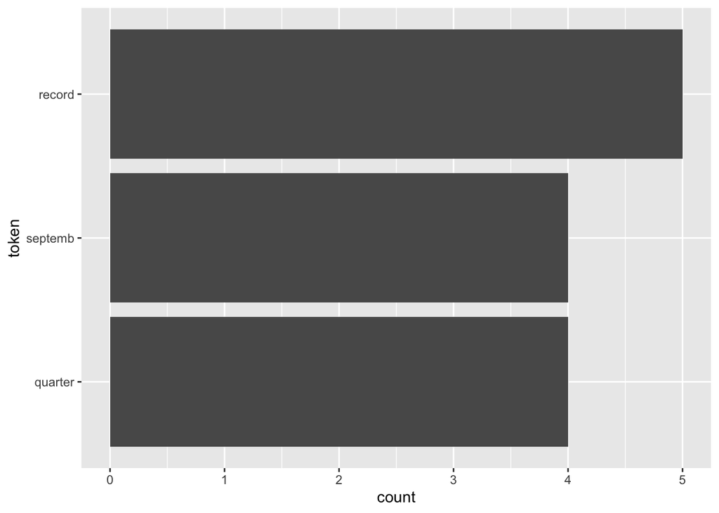

```r
pr_stemmed %>%
  group_by(stem) %>%
  summarize(count = n()) %>%
  arrange(desc(count)) %>%
  filter(count > 3) %>%
  mutate(token = reorder(stem, count)) %>%
  ggplot(aes(x=count, y=token)) + geom_col()
```

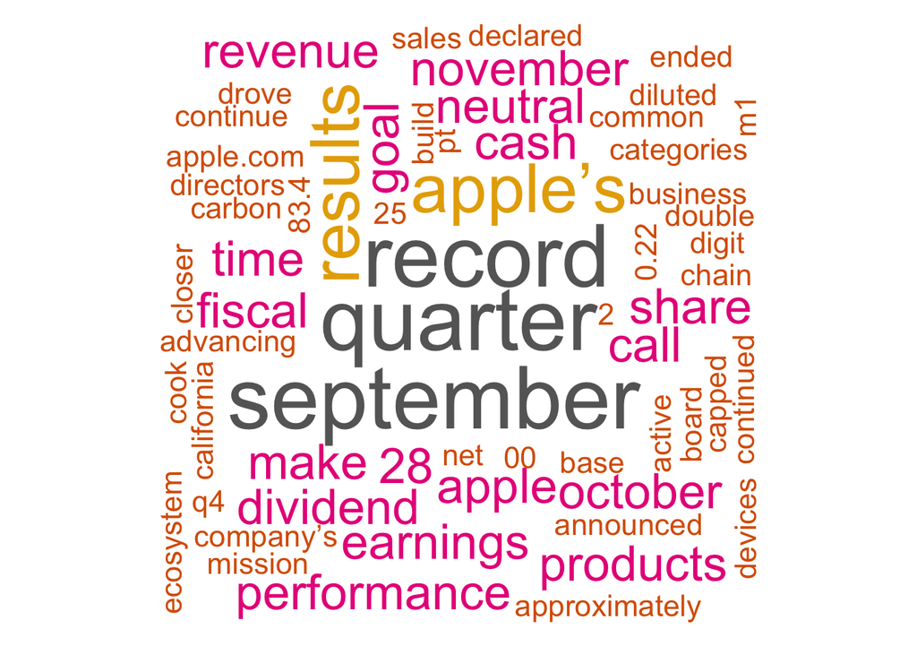

```r
# Key words
set.seed(77)

pr_stemmed %>%
  group_by(word) %>%
  summarize(count = n()) %>%
  with(wordcloud(words=word, freq=count, min.freq=1, max.words=100, random.order=F, rot.per=0.30, colors=brewer.pal(8, "Dark2")))
```

```r
# Sentiment total
# load finance sentiment list and explore it
lm_dict <- tidytext::get_sentiments('loughran')

# view dictionary
lm_dict %>% group_by(sentiment) %>% summarize(count = n())
```

```
## # A tibble: 6 × 2
##   sentiment    count
##   <chr>        <int>
## 1 constraining   184
## 2 litigious      904
## 3 negative      2355
## 4 positive       354
## 5 superfluous     56
## 6 uncertainty    297
```

```r
# add sentiment
pr_sentimented <- pr_stemmed %>%
  inner_join(lm_dict, by = 'word')

# explore totals
pr_sentimented %>% group_by(sentiment) %>% summarize(count = n())
```

```
## # A tibble: 2 × 2
##   sentiment   count
##   <chr>       <int>
## 1 positive        6
## 2 uncertainty     2
```

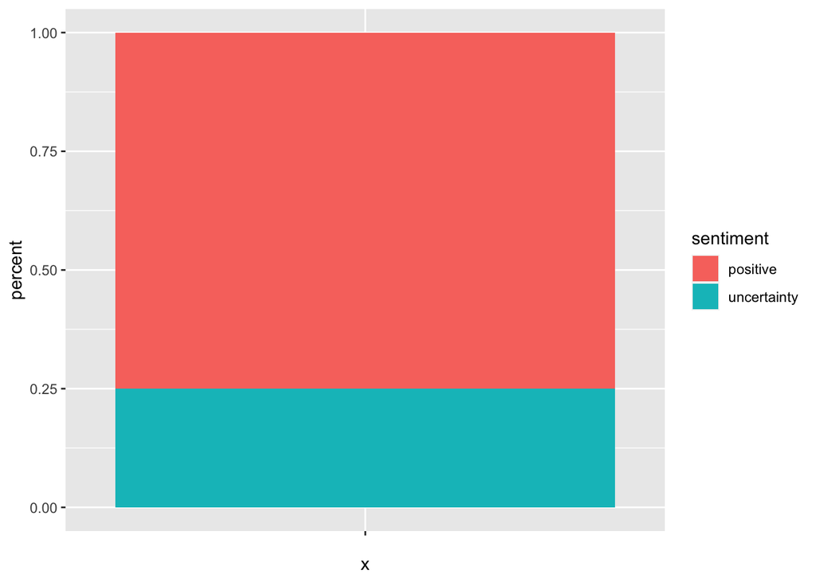

```r
pr_sentimented %>%
  group_by(sentiment) %>%
  summarize(count = n(), percent = count/nrow(pr_sentimented)) %>%
  ggplot(aes(x='', y=percent, fill=sentiment)) +
  geom_bar(width=1, stat='identity')
```

- 2c. After examining both of these text transcripts (MD&A and Press Release), use one or two paragraphs to explain several reasons for how and why these graphs are different. Be sure to mention how the percentage of sentiment differs between the two text strings and why you think they differ. Hint: To have a good reason for why they might have a different sentiment, you may need to research the purpose of the MD&A section and the purpose of the press release. You could also read the text and gain an understanding that way. These open ended answers will be graded on quality and not quantity (after meeting the minimum length). Exceptional answers will be specific, concise, insightful, and will utilize important insights from our classroom materials and from outside the classroom.

**Press releases are meticulously crafted to portray the company in the best possible light while remaining legally accurate and able to withstand auditing standards.**

**On the other hand, Management Discussion & Analysis is not auditable and reflects unscripted thoughts from the management team. These more off-the-cuff opinions may reveal underlying issues or uncertainties within the company. The sentiment analysis for Apple’s press release is overwhelmingly positive, with 25% uncertainty, while the MD&A sentiment analysis reveals a more complex, and likely more realistic, situation. In MD&A, uncertainty has increased significantly, and much of the positivity is replaced with a significant amount of negativity, followed by constraining and litigious sentiments.**